# Oyster Populations in Chesapeake Bay

tracking_oystRs

2023-12-05

# Introduction

Eastern oysters (*Crassostrea virginica*) are a staple species of the Chesapeake Bay region, the area in the Mid-Atlantic United States separated by the Delmarva Peninsula (pictured below).

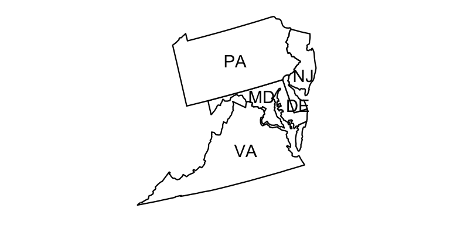

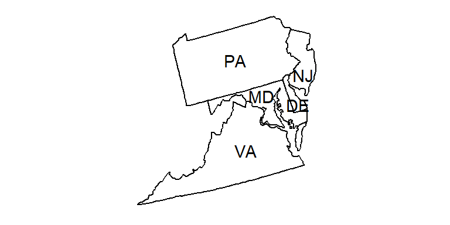

Oysters are a staple of aquatic regions such as this one, due to their cultural value, their contribution to the economy, and their role in environmental regulation.

## The Cultural Significance of Oysters

Oysters have long played a crucial role in the cultural history of the Chesapeake Bay. According to a cultural model assessment conducted by Paolisso and Dery (Paolisso and Dery 2010), the restoration of oyster populations in the region is a topic of significant importance. The study explores various oyster restoration alternatives and provides insights into the cultural perspectives surrounding these efforts. The cultural significance of oysters in the Chesapeake Bay extends beyond their ecological impact. Paolisso and Dery (Paolisso and Dery 2010) discuss how different restoration approaches are perceived within the local communities. Oysters are not merely a commodity; they are deeply embedded in the cultural fabric, shaping traditions and community practices. Understanding the cultural dimensions of oyster restoration is essential for developing sustainable and community-supported initiatives in the Chesapeake Bay region.

## Economic Importance

The resurgence of oyster populations would directly influence the growth of the economy, and unfortunately the decline in the health of the Bay influences the decline of it. According to the Chesapeake Bay Foundation, due to reduction of oyster harvesting both Virginia and Maryland have lost around $4 billion from their annual earnings. The ability to harvest oysters in the Bay area also creates a significant number of jobs which contributes to the local economy. The National Oceanic and Atmospheric Administration reported that around 34,000 jobs were provided by the Virginia and Maryland oyster industry in 2009.

## Oysters and Nitrogen Regulation

The value of nitrogen regulation emanates from the unique ability of oysters to serve as biofilters, actively improving water quality and averting adverse effects of nitrogen excess. One study shows that oysters play a role in mitigating nutrient pollution by filtering organic particles and phytoplankton from the water, effectively incorporating nitrogen into their tissues. This natural biofiltration process contributes to the prevention of issues like algal blooms and oxygen depletion (Beseres Pollack 2013). The study goes on to quantify the substantial nitrogen removal capacity of oyster reefs in the Mission-Aransas Estuary, further underscoring their role in denitrification and burial processes. Through their filtration activities, oysters emerge not only as contributors to improved water quality but also as key players in addressing the broader challenges associated with coastal nutrient enrichment.

## Environmental Impacts

Chesapeake Bay oysters face considerable challenges due to climate change and environmental variables like pH, salinity, water temperature, and nitrogen. The Bay, highly vulnerable to climate change, experiences rising seas, ocean acidification, warming water temperatures, and prolonged extreme weather, disrupting water quality, habitat, and wildlife. Oyster shell growth requires a sustained deposition of calcium carbonate, however, this is less available in acidic conditions leading to low calcification rates. Daily fluctuations in salinity have also been harmful to these oysters. They rely on freshwater input to survive, and parasites that infect oysters prosper in both high-salinity and warm environments. Too high or low salinity levels also lead to a decrease in immunity. Additionally, higher temperatures have led to waters being unable to hold as much dissolved oxygen (hypoxia). This condition has led to severe oyster mortality, reproductive failure, and high susceptibility to parasites and disease. These daily fluctuations of oxygen and acid have been intensified through the introduction of nitrogen and carbon dioxide from polluted air and runoff.

## Project Goal

The goal of this analysis is to determine which varying environmental factors are most directly responsible for the growth and decline of oyster populations in the Chesapeake Bay region. Additional, we aim to see if there is a statistically significant relationship between oyster population counts and the total amount of nitrogen present in the water.

# Methods

Data regarding oyster population was collected from the Choptank River, a Maryland tributary and the largest river in the Delmarva Peninsula. The data was accessed from the Biological & Chemical Oceanography Data Management Office, and was narrowed down to focus on market-sized sexually mature oysters. The data was reverted from a log-scale format to values capable of summation in Excel.

The environmental data was accessed from the Maryland Department of Natural Resources, specifically their long-term fixed station monthly monitoring database. This data was collected at three Choptank River stations to match the oyster population data, and the yearly averages for each type of data were determined using Excel.

A linear mixed-effect model predicting oyster population was developed using interactions between average pH, salinity, water temperature, and divergence in water temperature, creating the most complex model that could be analyzed with `dredge()` to find the best model. With this model, the random effect of location along the Choptank was included. The best-fitting model was analyzed with `Anova()` to see which factors and interactions were statistically significant.

To determine if there is a statistically significant relationship between oyster population and nitrogen content in the water, another linear model was developed and analyzed using `Anova()`.

# Results

## Environmental Factors

The data collected along the Choptank River varies depending on the location, but a few trends in oyster population across all locations can clearly be seen.

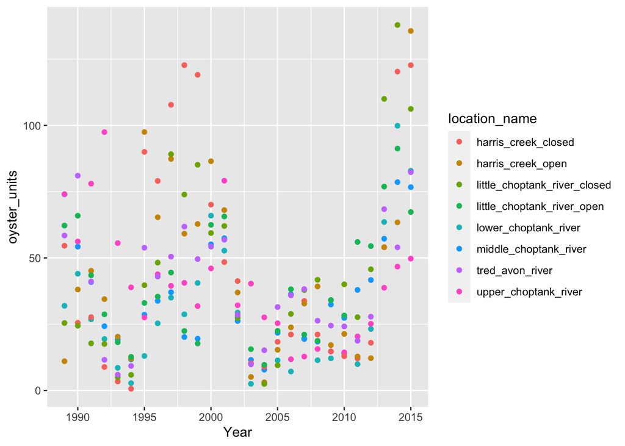

To get a better sense of these trends, the sum across all locations was calculated per year and graphed below.

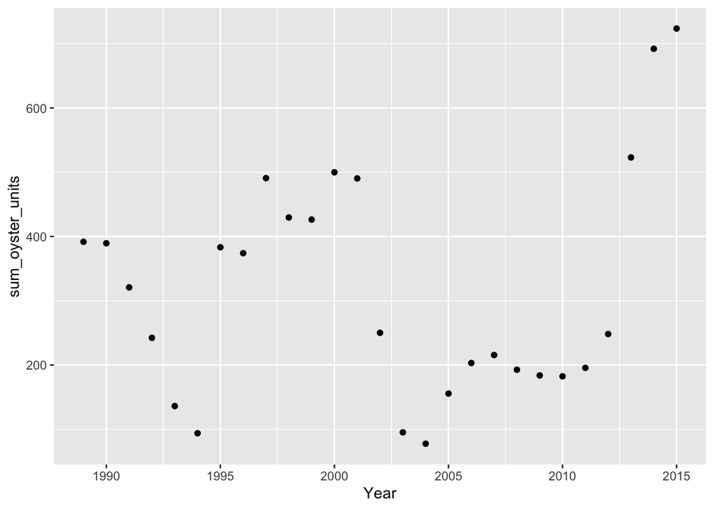

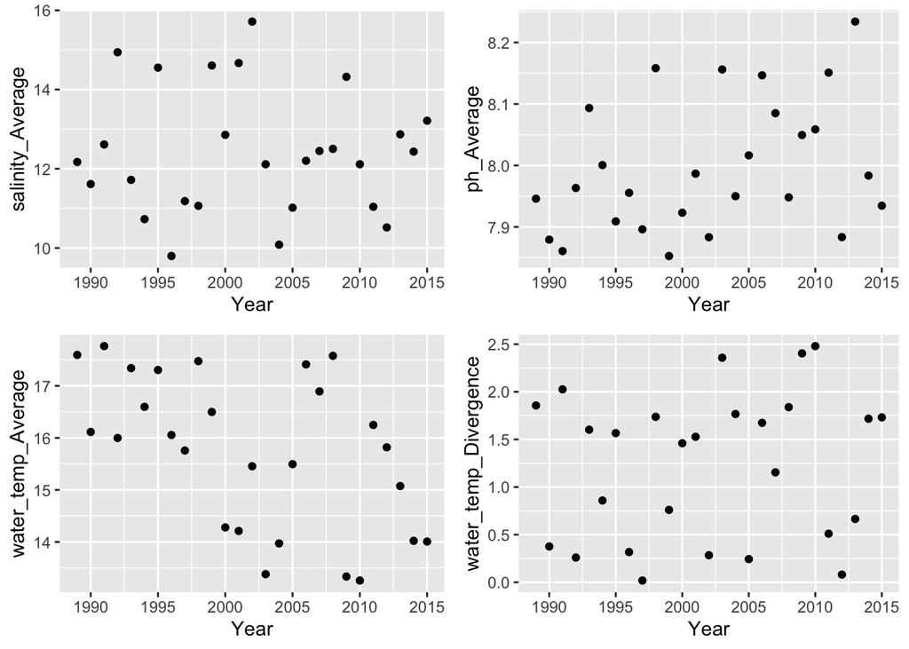

Each environmental factor was plotted against the oyster counts per location to try and see any clear patterns before using model analysis.

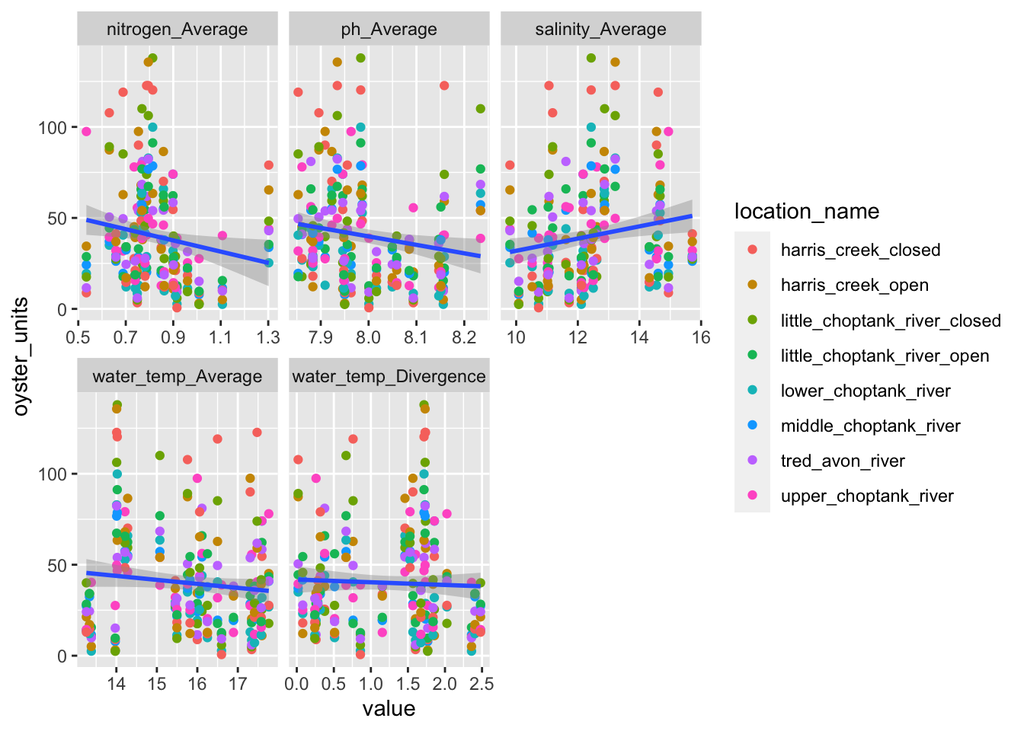

To determine which of these environmental factors influence oyster population values, the most complicated linear model is run through the `dredge()` function to determine the best-fitting nested models within that complex model.

Fit values for nested models of the most complicated lm model

|  | (Intercept) | ph_Average | salinity_Average | water_temp_Average | water_temp_Divergence | ph_Average:salinity_Average | ph_Average:water_temp_Average | ph_Average:water_temp_Divergence | salinity_Average:water_temp_Average | salinity_Average:water_temp_Divergence | water_temp_Average:water_temp_Divergence | ph_Average:salinity_Average:water_temp_Average | ph_Average:salinity_Average:water_temp_Divergence | ph_Average:water_temp_Average:water_temp_Divergence | salinity_Average:water_temp_Average:water_temp_Divergence | ph_Average:salinity_Average:water_temp_Average:water_temp_Divergence | df | logLik | AICc | delta | weight |
| --- | --- | --- | --- | --- | --- | --- | --- | --- | --- | --- | --- | --- | --- | --- | --- | --- | --- | --- | --- | --- | --- |
| 32768 | -60827.34 | 7728.538 | 2618.3711 | 4287.051 | -21574.511 | -333.93394 | -543.6042 | 2588.2577 | -201.644699 | 3173.640 | 465.7555 | 25.63293 | -389.0106 | -51.27962 | -125.6642960 | 15.21847 | 18 | -925.0726 | 1889.635 | 0.000000 | 9.650400e-01 |
| 16384 | -109286.25 | 13811.740 | 6386.9706 | 7357.291 | 2324.519 | -807.26970 | -929.0109 | -410.8253 | -440.818808 | 1318.559 | -1090.8028 | 55.67231 | -156.0722 | 144.04562 | -4.4603208 | NA | 17 | -929.7251 | 1896.557 | 6.921696 | 3.030526e-02 |
| 8192 | -80253.68 | 9995.459 | 4054.9737 | 5530.466 | 4389.537 | -500.89085 | -688.8212 | -560.3125 | -293.583886 | 1151.340 | -1150.4052 | 36.32624 | -143.8245 | 144.50262 | NA | NA | 16 | -932.7977 | 1900.343 | 10.707781 | 4.564363e-03 |
| 15360 | -13569.64 | 1638.351 | -673.8002 | 1428.294 | -1148.296 | 92.44663 | -174.8635 | 133.9936 | -3.980254 | 1203.797 | -837.5141 | NA | -150.7874 | 105.39710 | 0.1016357 | NA | 16 | -936.7200 | 1908.187 | 18.552410 | 9.035259e-05 |

The table above ranks the nested models based on how well they fit the data, with the best-fitting model at the top. Based on this analysis, the best-fitting model to explain oyster population numbers *is* the most complicated model, including all interactions. This is the model with the smallest AICc score and the highest weight. The model is as follows: `lmer(oyster_units~salinity_Average*ph_Average*water_temp_Average*water_temp_Divergence+(1|location_name)`.

To see if this relationship is statistically significant, an `Anova()` test can be performed.

Statistical test for best model, as determined by `dredge()`

|  | Chisq | Df | Pr(>Chisq) |
| --- | --- | --- | --- |
| salinity_Average | 13.5507841 | 2 | 0.0011415 |
| ph_Average | 1.7268912 | 2 | 0.4217065 |
| water_temp_Average | 32.0912065 | 2 | 0.0000001 |
| water_temp_Divergence | 43.7985808 | 4 | 0.0000000 |
| salinity_Average:ph_Average | 5.5940905 | 1 | 0.0180212 |
| salinity_Average:water_temp_Average | 8.4608365 | 1 | 0.0036287 |
| ph_Average:water_temp_Average | 1.5155680 | 1 | 0.2182914 |
| salinity_Average:water_temp_Divergence | 13.6727593 | 1 | 0.0002176 |
| ph_Average:water_temp_Divergence | 0.0012030 | 1 | 0.9723315 |
| water_temp_Average:water_temp_Divergence | 3.5069100 | 1 | 0.0611133 |
| salinity_Average:ph_Average:water_temp_Average | 5.9352732 | 1 | 0.0148408 |
| salinity_Average:ph_Average:water_temp_Divergence | 30.5573766 | 1 | 0.0000000 |
| salinity_Average:water_temp_Average:water_temp_Divergence | 2.0165187 | 1 | 0.1555955 |
| ph_Average:water_temp_Average:water_temp_Divergence | 14.3514518 | 1 | 0.0001517 |
| salinity_Average:ph_Average:water_temp_Average:water_temp_Divergence | 0.1541545 | 1 | 0.6945963 |

The `Anova()` test reveals that many of the components of the model have a statistically significant relationship with the oyster population data, as they have a small p-value that is less than 0.05. The following are all considered statistically significant by this measure: average salinity, average water temperature, divergence in average water temperature. As for interactions between these variables, the following are all significant based on p-value: salinity and water temperature, salinity and divergence in water temperature, salinity with pH and divergence in water temperature, and pH with water temperature and divergence in water temperature. The most significant factor with the lowest p-value is divergence in water temperature, which has a value of 7.064e-09.

## Relationship with Nitrogen

To answer the second question, average total nitrogen and total oyster units per year were compared in individual plots to first see if any patterns emerge at first glance.

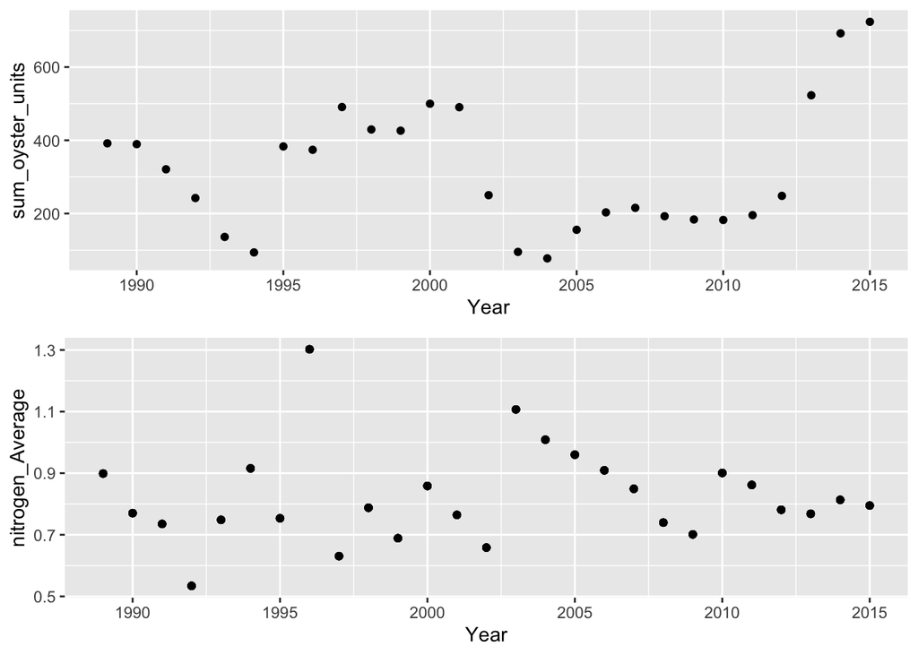

Average nitrogen content and oyster population plotted between 1989 and 2015

Looking at the initial patterns of the graph, barring a handful of outliers, it seems that the oyster population and the amount of nitrogen present in the water have an inverse relationship. Instances of this pattern can be seen between 1992 and 1994 and between 2003 and 2004, where some of the lowest oyster counts match with some of the highest nitrogen content. Now comes the big question: is this relationship statistically significant, or is this seemingly-related variance more likely due to chance?

Statistical test for model predicting nitrogen content based on oyster population

|  | Sum Sq | Df | F value | Pr(>F) |
| --- | --- | --- | --- | --- |
| oyster_units | 0.1268073 | 1 | 5.747565 | 0.0173748 |
| Residuals | 4.6993750 | 213 | NA | NA |

The `Anova()` test of the `nit.lm` model reveals a p-value of 0.0173748, which is below the 0.05 value of significance and therefore indicates a statistically significant relationship.

# Discussion

Based on the `dredge()` nested model analysis, the best-fitting model was determined to contain all of the environmental variables and interactions, or `lmer(oyster_units~salinity_Average*ph_Average*water_temp_Average*water_temp_Divergence+(1|location_name)`. While all factors were involved in the best model, the most statistically significant variable was divergence in water temperature with the lowest p-value. This suggests that higher yearly variation from an average temperature, which means more temperature anomalies during the year, can impact the ability of the oysters to survive to maturity. Harmful variation can include “colder colds” and “hotter hots”, as either anomaly represents a change from the best conditions for oysters. This aligns with previous water temperature research, which discovered that some oyster species function best between 28°C and 32°C, specifically during development (Muhammad, Atsumi, and Komaru 2020). If the proper temperature conditions are not met in embryonic and larval development, the oysters will not survive long enough to reach this sexually mature market-sized state.

This has important implications regarding climate change, as more erratic weather patterns encompassing both extremes are becoming more common as the climate of Earth changes.

## Limitations

A major limitation in our analysis is the availability of oyster population data, as we were only able to find the population counts for a twenty-six-year period. With this limited range, it does not take a large number of outlying data points to influence the data and keep the models from fitting in a statistically significant way. Additionally, the data for these oysters ends at 2015, meaning that the last eight years are not included. The rate of climate change has been accelerating , so more drastic environmental changes and their effects on oysters would likely be seen if the timeline of the data included present day.

## Next Steps

If this research were to continue, it would be essential to have the most up-to-date oyster population information, as previously mentioned. Additionally, a great way to expand this project would be to examine the oyster populations across other regions to compare and contrasts how different areas are feeling the effects of climate change and declining populations. The project could be expanded further by looking at other species, either other oyster species or other aquatic species that are impacted by changing ocean conditions. If multiple oyster species were considered in the data set, we could see if certain species are put at a greater risk than others.

# Author Contributions

Audrey: Finding data,

Conor: Cultural importance of Oysters & research

Jessica: Introduction and conducted background research to find potential data sources.

Susanne: Oyster and nitrogen regulation & Environmental impacts

# Bibliography

Beseres Pollack, David AND Kim, Jennifer AND Yoskowitz. 2013. “Role and Value of Nitrogen Regulation Provided by Oysters (Crassostrea Virginica) in the Mission-Aransas Estuary, Texas, USA.” *PLOS ONE* 8 (6): 1–8. https://doi.org/10.1371/journal.pone.0065314.

Humphries, Austin T, Suzanne G Ayvazian, Joanna C Carey, Boze T Hancock, Sinead Grabbert, Donald Cobb, Charles J Strobel, and Robinson W Fulweiler. 2016. “Directly Measured Denitrification Reveals Oyster Aquaculture and Restored Oyster Reefs Remove Nitrogen at Comparable High Rates.” *Frontiers in Marine Science* 3: 74.

Muhammad, Gunawan, Takashi Atsumi, and Akira Komaru. 2020. “The Influence of Water Temperature, Salinity and Food Availability on Nacre Deposition Rates in Shells and Pearls of Japanese and Hybrid Pearl Oyster, Pinctada Fucata ().” *Aquaculture* 528: 735512.

Paolisso, Michael, and Nicole Dery. 2010. “A Cultural Model Assessment of Oyster Restoration Alternatives for the Chesapeake Bay.” *Human Organization* 69 (2): 169–79.